# Module 06: Computational Text Analysis

## 7.5 Reading the LDA Output — Top Words Per Topic

```r
# beta matrix: P(word | topic) — how strongly each word is associated with each topic
# This is the primary output to interpret

topic_words <- tidy(lda_model, matrix="beta") |>
  group_by(topic) |>
  slice_max(beta, n=12) |>  # top 12 words per topic
  ungroup()

cat("=== TOP WORDS PER TOPIC ===\n")
```

```
## === TOP WORDS PER TOPIC ===
```

```r
cat("Each word's beta = P(word | topic) — its probability under that topic.\n\n")
```

```
## Each word's beta = P(word | topic) — its probability under that topic.
```

```r
topic_words |>
  dplyr::select(topic, term, beta) |>
  mutate(beta=round(beta,5)) |>
  pivot_wider(names_from=topic, values_from=beta,
              names_prefix="Topic_") |>
  head(12) |>
  print()
```

```
## # A tibble: 12 × 6
##    term     Topic_1  Topic_2 Topic_3  Topic_4 Topic_5
##    <chr>      <dbl>    <dbl>   <dbl>    <dbl>   <dbl>
##  1 law      0.0223  NA       NA      NA       NA
##  2 upon     0.0200   0.00955 NA      NA       NA
##  3 govern   0.0162   0.0273  NA      NA       NA
##  4 peopl    0.0147   0.0114   0.0195 NA       NA
##  5 shall    0.0127   0.00757 NA      NA       NA
##  6 must     0.0118  NA       NA       0.0107  NA
##  7 congress 0.0108  NA       NA      NA       NA
##  8 secur    0.0106  NA       NA      NA       NA
##  9 now      0.00986 NA       NA       0.00906 NA
## 10 polici   0.00928 NA       NA      NA       NA
## 11 make     0.00837 NA       NA      NA       NA
## 12 great    0.00762 NA       NA      NA        0.0140
```

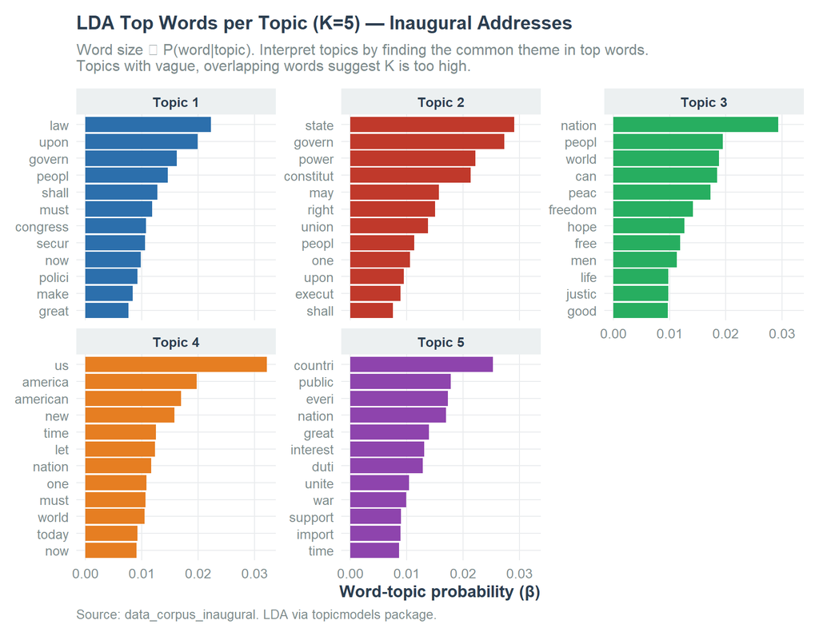

```r
ggplot(topic_words, aes(x=beta, y=reorder_within(term, beta, topic),
                         fill=factor(topic))) +
  geom_col(show.legend=FALSE) +
  facet_wrap(~paste("Topic", topic), scales="free_y", ncol=3) +
  scale_y_reordered() +
  scale_fill_manual(values=css_palette(K)) +
  labs(
    title    = paste0("LDA Top Words per Topic (K=", K, ") — Inaugural Addresses"),
    subtitle = paste("Word size ∝ P(word|topic).",
                     "Interpret topics by finding the common theme in top words.",
                     "\nTopics with vague, overlapping words suggest K is too high."),
    x="Word-topic probability (β)", y=NULL,
    caption  = "Source: data_corpus_inaugural. LDA via topicmodels package."
  ) +
  theme(strip.text=element_text(face="bold"))
```

**Reading this plot:** Each panel is one topic. Words with longer bars are more characteristic of that topic. Your job is to read the top words and infer the theme. Common patterns:

- A clear theme: top words cluster around an obvious concept (“nation,” “people,” “government,” “free,” “citizen” → civic republicanism)
- A time-period topic: words associated with a historical period’s vocabulary rather than a substantive theme
- A garbage topic: miscellaneous words without clear theme → suggests K is too high or preprocessing was inadequate

**Name each topic.** Work through the top 15–20 words (not just 10), read 3–5 documents that score highly on that topic, and then assign a label. Document your reasoning.

## 7.6 Document-Topic Proportions

```r
# gamma matrix: P(topic | document) — how much each document is about each topic
doc_topics <- tidy(lda_model, matrix="gamma") |>
  left_join(
    tibble(document=rownames(dfm_lda),
           Year=docvars(dfm_lda,"Year"),
           President=docvars(dfm_lda,"President")),
    by="document"
  ) |>
  mutate(topic=paste("Topic", topic))

cat("=== DOCUMENT-TOPIC PROPORTIONS (gamma) ===\n")
```

```
## === DOCUMENT-TOPIC PROPORTIONS (gamma) ===
```

```r
cat("Each document has a proportion for each topic; they sum to 1.\n\n")
```

```
## Each document has a proportion for each topic; they sum to 1.
```

```r
doc_topics |>
  filter(President %in% c("Lincoln","Roosevelt","Obama","Trump")) |>
  pivot_wider(names_from=topic, values_from=gamma) |>
  dplyr::select(President, Year, starts_with("Topic")) |>
  mutate(across(starts_with("Topic"), ~round(.x,3))) |>
  kbl(caption="Topic Proportions for Selected Presidents") |>
  kable_styling(bootstrap_options=c("striped","hover")) |>
  footnote(general="Each row sums to 1. Dominant topic = highest proportion.")
```

Topic Proportions for Selected Presidents

| President | Year | Topic 1 | Topic 2 | Topic 3 | Topic 4 | Topic 5 |
| --- | --- | --- | --- | --- | --- | --- |
| Lincoln | 1861 | 0.267 | 0.511 | 0.066 | 0.060 | 0.096 |
| Lincoln | 1865 | 0.084 | 0.188 | 0.225 | 0.247 | 0.256 |
| Roosevelt | 1905 | 0.137 | 0.137 | 0.370 | 0.212 | 0.145 |
| Roosevelt | 1933 | 0.255 | 0.108 | 0.295 | 0.216 | 0.126 |
| Roosevelt | 1937 | 0.170 | 0.100 | 0.360 | 0.276 | 0.094 |
| Roosevelt | 1941 | 0.067 | 0.163 | 0.319 | 0.351 | 0.100 |
| Roosevelt | 1945 | 0.100 | 0.097 | 0.381 | 0.291 | 0.131 |
| Obama | 2009 | 0.066 | 0.052 | 0.245 | 0.522 | 0.115 |
| Obama | 2013 | 0.063 | 0.067 | 0.233 | 0.539 | 0.098 |
| Trump | 2017 | 0.082 | 0.057 | 0.143 | 0.641 | 0.076 |
| Trump | 2025 | 0.136 | 0.084 | 0.124 | 0.547 | 0.109 |

Note:  
Each row sums to 1. Dominant topic = highest proportion.

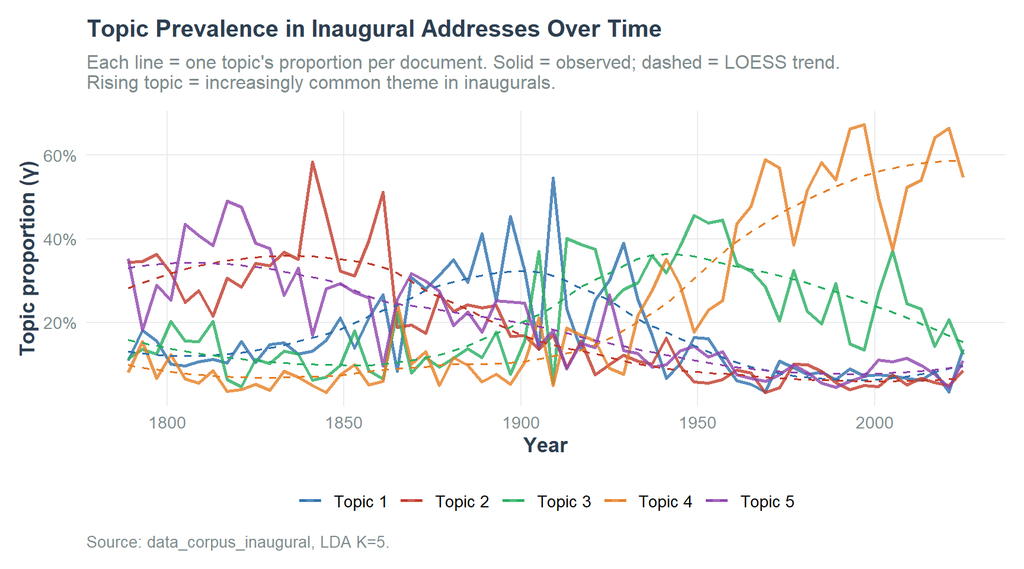

```r
# How has the prevalence of each topic changed over time?
doc_topics |>
  filter(!is.na(Year)) |>
  ggplot(aes(x=Year, y=gamma, colour=topic, group=topic)) +
  geom_line(linewidth=0.9, alpha=0.8) +
  geom_smooth(method="loess", span=0.6, se=FALSE,
              linewidth=0.6, linetype="dashed") +
  scale_colour_manual(values=css_palette(K), name=NULL) +
  scale_y_continuous(labels=scales::percent) +
  labs(
    title    = "Topic Prevalence in Inaugural Addresses Over Time",
    subtitle = paste("Each line = one topic's proportion per document.",
                     "Solid = observed; dashed = LOESS trend.",
                     "\nRising topic = increasingly common theme in inaugurals."),
    x="Year", y="Topic proportion (γ)",
    caption  = "Source: data_corpus_inaugural, LDA K=5."
  ) +
  theme(legend.position="bottom")
```